# TP2

Abdallah DAABOUL

24 mai 2019

# Exercice 1

## Q1

Irréductible et apériodique : Ro=0.3  
Irréductible non apériodique: Ro=0 –> période=2  
Non irréductible : Ro=0.5

## Q2 Fonctions EtatSuivant

```r
#Fonction renvoyant l'etat suivant de la chaine
EtatSuiv=function(i,Q){
  lg=length(Q)
  p=Q[i,]
  p1 = c(0, p[1:lg-1])
  t = runif(1)
  u = (t > cumsum(p1)) & (t < cumsum(p))
  X = which(u==1)
  return (X)
}
```

## Q3 Tracer les trajectoires pour différents Ro

```r
#Creation de la matrice Q
Q=function(RO){
  return(rbind(c(RO, 0.5, 0,0.5-RO), c(1/2+RO, 0, 1/2-RO,0),c(0, 1/2-RO ,RO, 1/2),c(0.5-RO,0,0.5+RO,0))) #Creation de la matrice
}
```

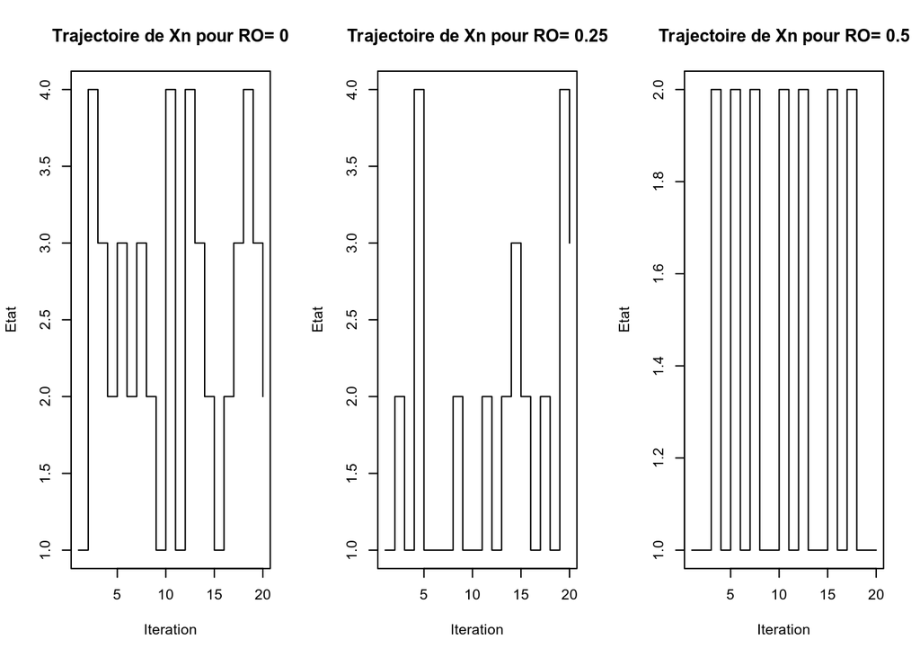

```r
#Trajectoire de la chaine
n=20
Etat=rep(NA,20)
Etat[1]=1

par(mfrow=c(1,3))
for(Z in c(0,0.25,0.5)){
for(t in 2:n){     #n=20
  Etat[t]=EtatSuiv(Etat[t-1],Q(Z))   #Je stocke l état de chaque itération
}
Iteration=1:20
plot(Iteration,Etat,type="s",main = paste("Trajectoire de Xn pour RO=",Z))

}
```

## Q4 Détermination des valeurs invariantes

On remarque que nous pouvons remplacer le système pi*p=pi par p’pi’=pi’  
Alors le vecteur pi sera le vecteur correspondant à la valeur propre 1 .  
On divise pi par la somme de ses composantes pour avoir une somme de pi = 1

```r
#Fonction Renvoyant la loi invariante correspondante
LoiInv=function(M){
tM=t(M) #Transposé de M
Propres=eigen(tM)
pi=Propres$vectors[,1] / sum(Propres$vectors[,1])
return(pi)
}
```

```r
pi0=LoiInv(Q(0))
print(pi0)
```

```
## [1] 0.25 0.25 0.25 0.25
```

```r
pi025=LoiInv(Q(0.25))
print(pi025)
```

```
## [1] 0.2857143 0.2142857 0.2857143 0.2142857
```

```r
pi050=LoiInv(Q(0.5))
print(pi050)
```

```
## [1] 0.6666667 0.3333333 0.0000000 0.0000000
```

```r
#Affichage des valeurs propres de Q(0.5)
print(eigen(Q(0.5)))
```

```
## eigen() decomposition
## $values
## [1]  1.0  1.0 -0.5 -0.5
##
## $vectors
##           [,1]      [,2]       [,3]       [,4]
## [1,] 0.7071068 0.0000000 -0.4472136  0.0000000
## [2,] 0.7071068 0.0000000  0.8944272  0.0000000
## [3,] 0.0000000 0.7071068  0.0000000 -0.4472136
## [4,] 0.0000000 0.7071068  0.0000000  0.8944272
```

Pour le cas de Ro=0.5, en affichant les valeurs propres, nous remarquons que 1 est une valeur propre double. Ce qui correspond aux 2 classes de récurrence de cette matrice. Donc la loi stationnaire est une combinaison linéaire des deux classes et donc nous avons une infinité de possibilité.

## Q5 Les cas où le théorème ergodique est applicable

Pour Ro=0 et 0.25 les 2 chaines sont irréductibles et donc le théorème ergodique est applicable dans ces 2 cas.

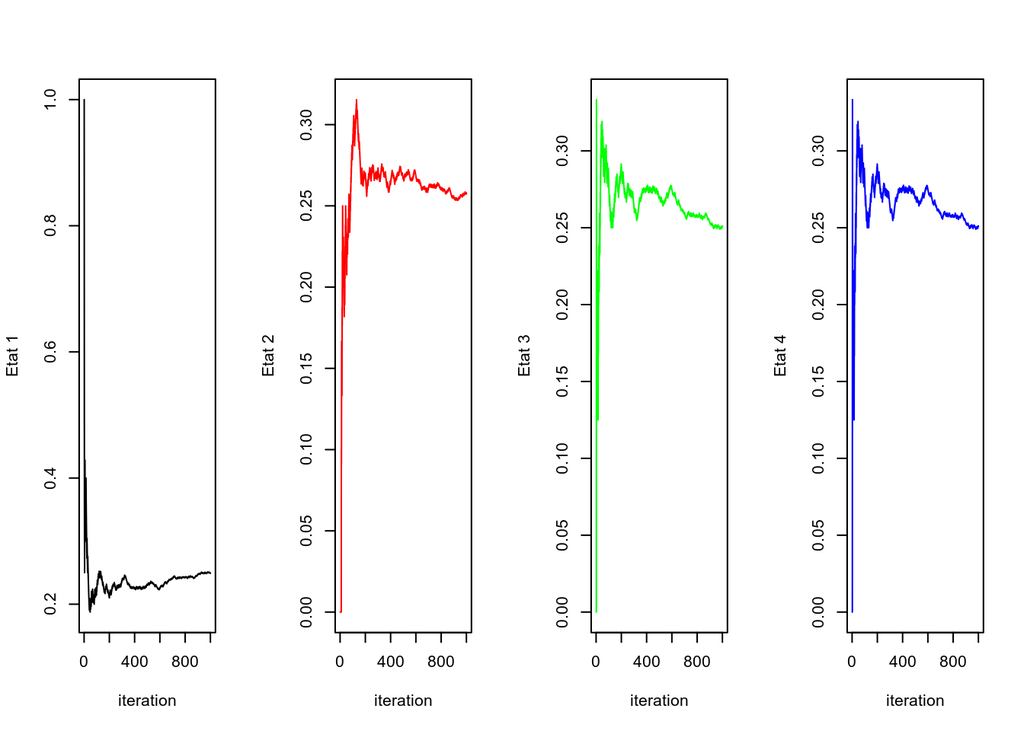

```r
#fonction qui simule n etat
simul <- function(n,M,P0){
  X = rep(0,times=n)
  l = length(M)
  p1 = c(0,P0[1:l-1])
  t = runif(1)
  u = (t > cumsum(p1)) & (t < cumsum(P0))
  X[1] = which(u==1)

  for(i in 2:n){
    X[i]=EtatSuiv(X[i-1],M)
  }
  return (X)
}

P0 = c(1,0,0,0)

T=seq(1,1000)

#Pour Ro=0

X = simul(1000,Q(0),P0)
f1 = cumsum(X==1)/T
f2 = cumsum(X==2)/T
f3 = cumsum(X==3)/T
f4 = cumsum(X==4)/T

par(mfrow=c(1,4))
plot(f1,type='l',xlab=("iteration"),ylab=("Etat 1"))
plot(f2,type='l',col='red',xlab=("iteration"),ylab=("Etat 2"))
plot(f3,type='l',col='green',xlab=("iteration"),ylab=("Etat 3"))
plot(f3,type='l',col='blue',xlab=("iteration"),ylab=("Etat 4"))
```

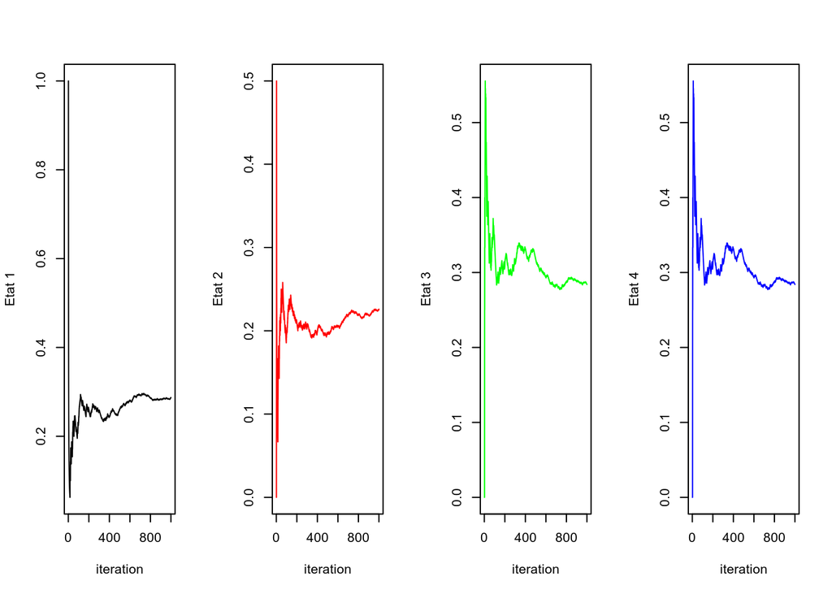

```r
#Pour Ro=0.25

X = simul(1000,Q(0.25),P0)
f1 = cumsum(X==1)/T
f2 = cumsum(X==2)/T
f3 = cumsum(X==3)/T
f4 = cumsum(X==4)/T

par(mfrow=c(1,4))
plot(f1,type='l',xlab=("iteration"),ylab=("Etat 1"))
plot(f2,type='l',col='red',xlab=("iteration"),ylab=("Etat 2"))
plot(f3,type='l',col='green',xlab=("iteration"),ylab=("Etat 3"))
plot(f3,type='l',col='blue',xlab=("iteration"),ylab=("Etat 4"))
```

Nous remarquons que dans les 2 cas, les courbes représentant chacun des états convergent bien à leur valeur correspondante dans la loi invariante.

## Q6

Pour Ro=0.025 loi chaine et irréductible et apériodique, donc on a la convergence en loi

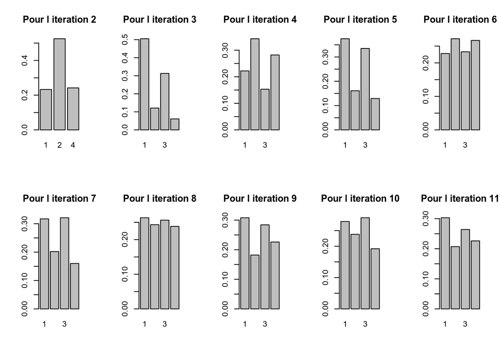

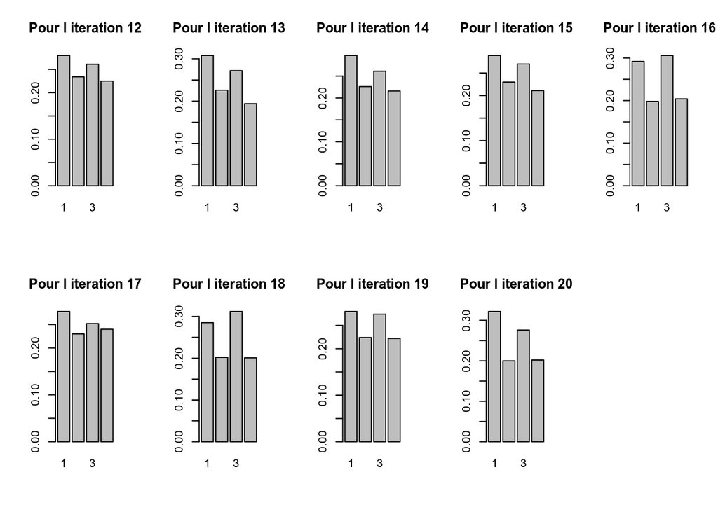

```r
#Simulation de 1000 trajectoires de 20 itérations
#Pour Ro=0.25
Trajectoires=matrix(0,1000,20)
for(cpt in 1:1000){
  Trajectoires[cpt,] = simul(20,Q(0.25),P0)
}
par(mfrow=c(2,5))
for(i in 2:20){
  barplot(table(Trajectoires[,i])/1000,beside=TRUE,main = paste('Pour l iteration',i))
}
```

Nous remarquons que les bars convergent bien vers la loi stationnaire pour Q=0.25 -> (0.28 0.21 0.28 0.21)

Pour montrer la non convergence pour Ro=0.5, je vais prendre deux états initials différents (0,0,0,1) et (1,0,0,0)

#### Q(0.5) partant de 4

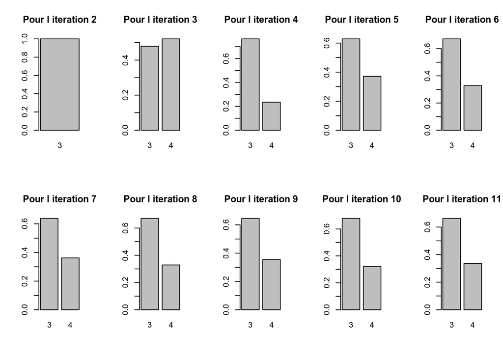

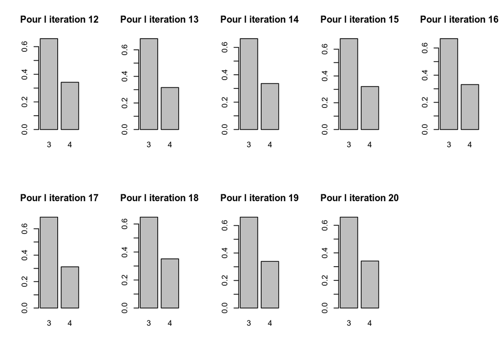

```r
Q0_partant_de_4=matrix(0,1000,20)
for(cpt in 1:1000){
  Q0_partant_de_4[cpt,] = simul(20,Q(0.5),c(0,0,0,1))
}
par(mfrow=c(2,5))
for(i in 2:20){
  barplot(table(Q0_partant_de_4[,i])/1000,beside=TRUE,main = paste('Pour l iteration',i))
}
```

#### Q(0.5) partant de 1

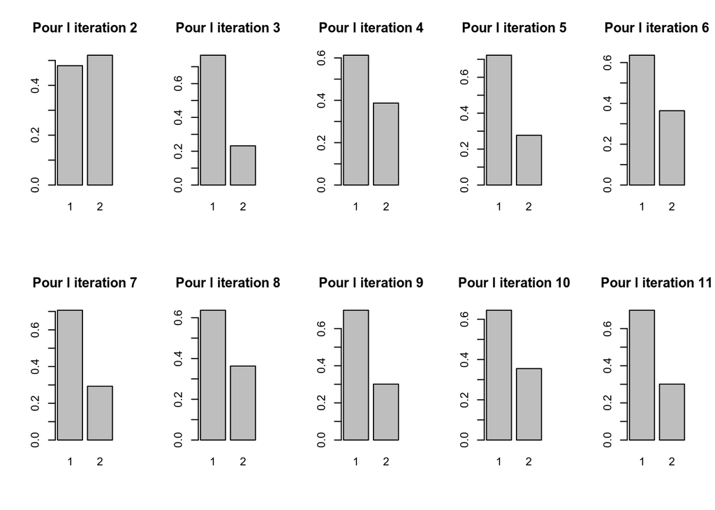

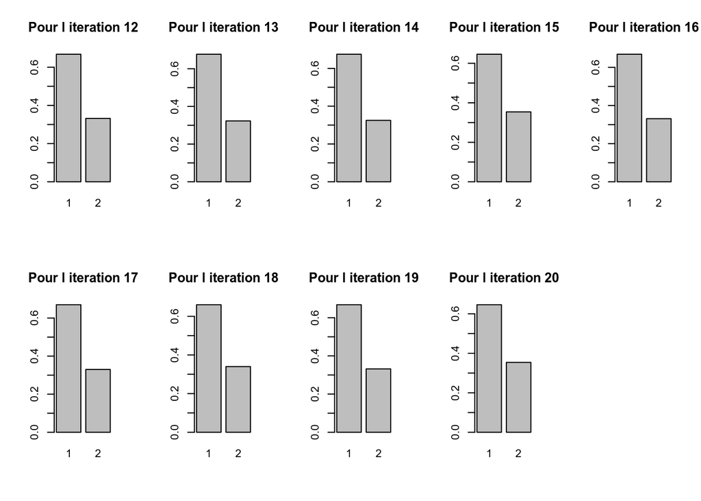

```r
Q0_partant_de_1=matrix(0,1000,20)
for(cpt in 1:1000){
  Q0_partant_de_1[cpt,] = simul(20,Q(0.5),c(1,0,0,0))
}
par(mfrow=c(2,5))
for(i in 2:20){
  barplot(table(Q0_partant_de_1[,i])/1000,beside=TRUE,main = paste('Pour l iteration',i))
}
```

Pour le cas où Ro=0.5 la convergence dépend de l’état initial donc pas de convergence en loi . Partant de 3 ou 4 nous serons toujours bloqués dans ces deux états, et de même partant de 1 ou 2.

## Q7 Temps de retour à un état

```r
#Fonction renvoyant le temps necéssaire pour revenir à l'état s
TempsRetour=function(s,Ro){
n=1
t=EtatSuiv(s,Q(Ro))
while(t != s){
t=EtatSuiv(t,Q(Ro))
n=n+1
}
return(n)
}
```

## Q8

```r
#Fonction qui retourne l'espérence
EstimerEsperence=function(s,Ro){
  somme=0
  for (i in 1:1000){
    somme=somme+TempsRetour(s,Ro)
  }
  return(somme/1000)
}
```

```r
print(EstimerEsperence(1,0))    #esperence pour q=0
```

```
## [1] 4.108
```

```r
print(EstimerEsperence(1,0.25)) #esperence pour q=0.25
```

```
## [1] 3.441
```

```r
print(EstimerEsperence(1,0.5))  #esperence pour q=0.5
```

```
## [1] 1.542
```

```r
#partieb
Mu0=c(1/EstimerEsperence(1,0),1/EstimerEsperence(2,0),1/EstimerEsperence(3,0),1/EstimerEsperence(4,0))
Mu025=c(1/EstimerEsperence(1,0.25),1/EstimerEsperence(2,0.25),1/EstimerEsperence(3,0.25),1/EstimerEsperence(4,0.25))
Mu050=c(1/EstimerEsperence(1,0.5),1/EstimerEsperence(2,0.5),1/EstimerEsperence(3,0.5),1/EstimerEsperence(4,0.5))

print(Mu0)
```

```
## [1] 0.2459420 0.2508781 0.2536783 0.2464268
```

```r
print(Mu025)
```

```
## [1] 0.2964720 0.2223210 0.2723312 0.1996406
```

```r
print(Mu050)
```

```
## [1] 0.6657790 0.3244646 0.6729475 0.3363606
```

# Exercice2

## Q1 Methode de Metropolis

```r
f=function(u,v){
  return(exp(-10*(u*u-v)^2-(v-1/4)^4))
}


MetropolisHastings=function(i,sigma,n){
  X=matrix(NA,n,2)
  X[1,1]=i[1]
  X[1,2]=i[2]
  for (j in 2:n){
    eps=rnorm(2,0,sigma)
    ksi=X[j-1]+eps


    r=f(ksi[1],ksi[2])/f(X[j-1,1],X[j-1,2])

    u=runif(1,0,1)
    if(u<=r){
      X[j,1]=ksi[1]
      X[j,2]=ksi[2]
    }
    else{
      X[j,1]=X[j-1,1]
      X[j,2]=X[j-1,2]
    }
  }
  return(X)
}
```

# Q2 Methode de Metropolis

```r
#Algo Proposé
u=seq(-2,2,0.1)
v=seq(-2,2,0.1)
z=outer(u,v,f)
```

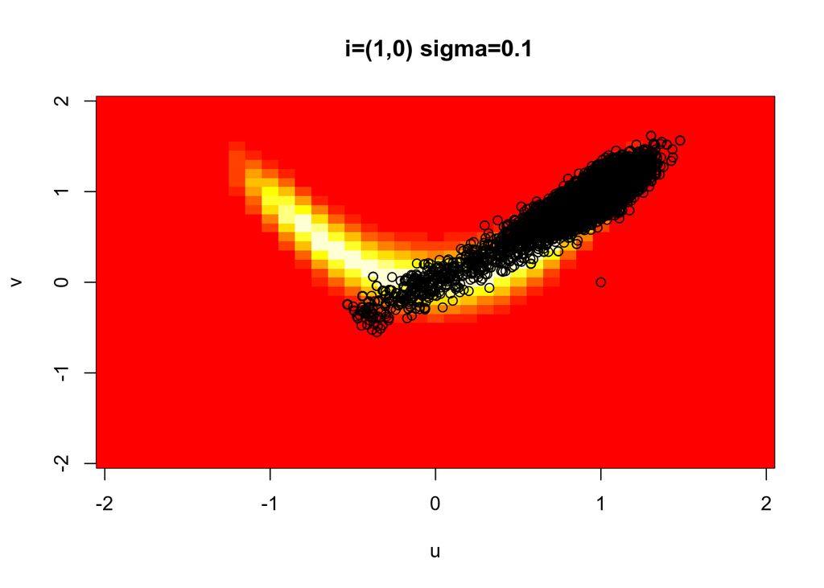

```r
n=10000

P1=MetropolisHastings(c(1,0),0.1,n)
image(u,v,z,main=paste(" i=(1,0) sigma=0.1"))
points(P1)
```

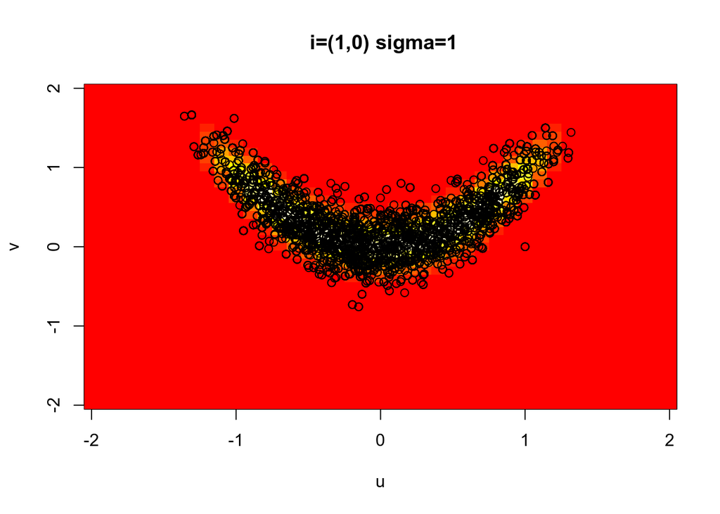

```r
P2=MetropolisHastings(c(1,0),1,n)
image(u,v,z,main=paste(" i=(1,0) sigma=1"))
points(P2)
```

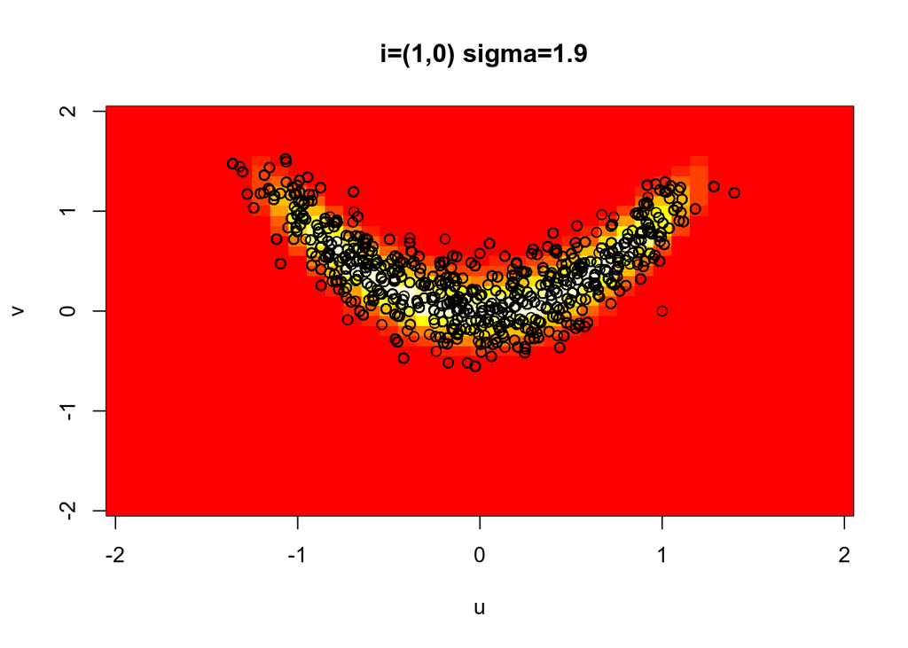

```r
P3=MetropolisHastings(c(1,0),1.9,n)
image(u,v,z,main=paste(" i=(1,0) sigma=1.9"))
points(P3)
```

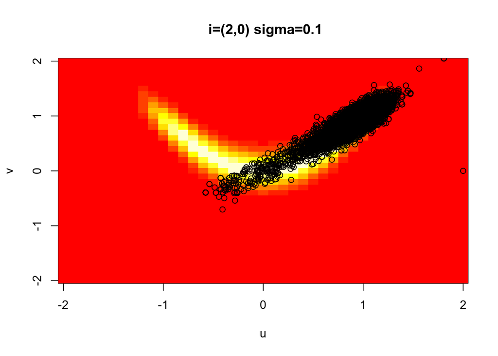

```r
P4=MetropolisHastings(c(2,0),0.1,n)
image(u,v,z,main=paste(" i=(2,0) sigma=0.1"))
points(P4)
```

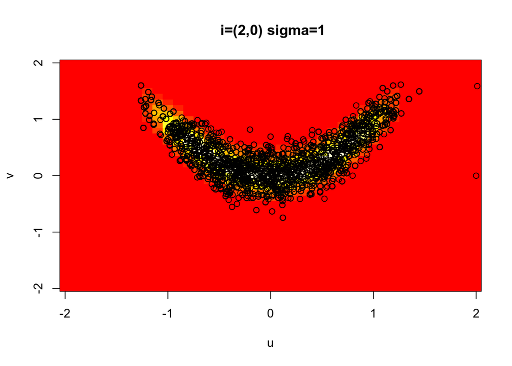

```r
P5=MetropolisHastings(c(2,0),1,n)
image(u,v,z,main=paste(" i=(2,0) sigma=1"))
points(P5)
```

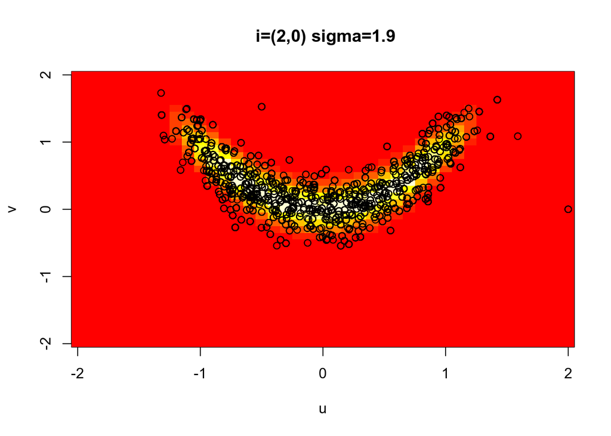

```r
P6=MetropolisHastings(c(2,0),1.9,n)
image(u,v,z,main=paste(" i=(2,0) sigma=1.9"))
points(P6)
```

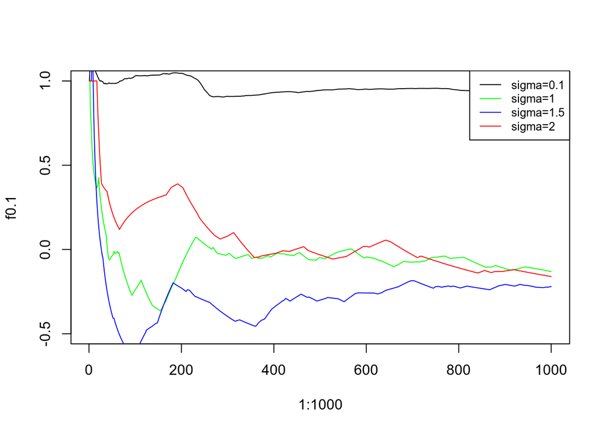

```r
#3
x0=c(1,0)

X0.1=MetropolisHastings(x0,0.1,1000)
f0.1 = cumsum(X0.1[,1])/(1:1000)
plot(1:1000,f0.1,type='l',col="black",ylim=c(-0.5,1))
legend("topright", paste(c("sigma=0.1", "sigma=1","sigma=1.5","sigma=2")),
       col=c("black","green","blue", "red"), lty=1, cex=0.8)

X1=MetropolisHastings(x0,1,1000)
f1 = cumsum(X1[,1])/(1:1000)
lines(1:1000,f1,type='l',col="green")

X1.5=MetropolisHastings(x0,1.5,1000)
f1.5 = cumsum(X1.5[,1])/(1:1000)
lines(1:1000,f1.5,type='l',col="blue")

X2=MetropolisHastings(x0,2,1000)
f2 = cumsum(X2[,1])/(1:1000)
lines(1:1000,f2,type='l',col="red")
```

# Exercice 3

## Q1, Fonction Ehrenfest

```r
Ehrenfest <- function (x,Q)
{
  r = runif(1) # on simule une loi uniforme
  # on regarde ou la boule a le plus de chance d'être et on la déplace
  if(r <= (x/N))
  {
    return(x-1)
  }
  else
  {
    return(x+1)
  }
}

N=10
M=matrix(0,N+1,N+1)
for (i in 1:N)
{
  M[i+1,i]=(i)/N
  M[i,i+1]=(N-i+1)/N
}
```

## Q2, Fonction Simulation et trajectoire

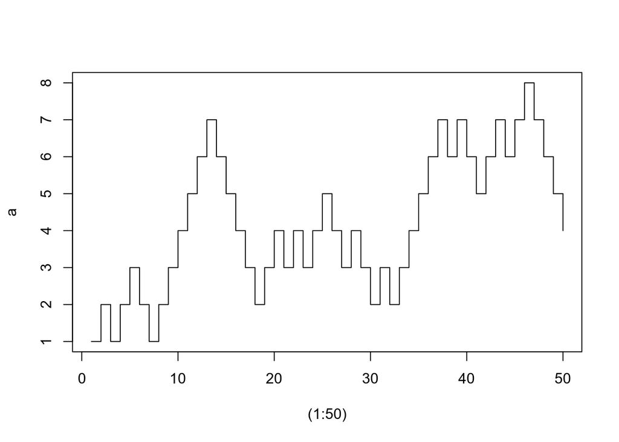

```r
simulation <- function (etat1, n,Mat)
{
  etats=rep(NA,n)
  etats[1]=etat1
  for (i in (2:n))
  {
    etats[i]= Ehrenfest(etats[i-1],Mat)
  }
  return(etats)
}

a=(simulation(1,50,M))
plot ((1:50),a,type='s')
```

##Q3

```r
Pt= t(M)
P=eigen(Pt)

# normalise
x=P$vectors[,1]
x[1:11]=x[1:11]/sum(x)
PI=x  # loi stationnaire
PI
```

```
##  [1] 0.0009765625 0.0097656250 0.0439453125 0.1171875000 0.2050781250
##  [6] 0.2460937500 0.2050781250 0.1171875000 0.0439453125 0.0097656250
## [11] 0.0009765625
```

```r
#pour verifier  PI%*%M
```

Comme la matrice de transition a une seule valeur propre egale a 1 alors sa loi stationnaire est unique. ##Q4,5

```r
k=0:10
p=0.5
pk=choose(N,k)*p^k*(1-p)^(N-k)
print(pk)
```

```
##  [1] 0.0009765625 0.0097656250 0.0439453125 0.1171875000 0.2050781250
##  [6] 0.2460937500 0.2050781250 0.1171875000 0.0439453125 0.0097656250
## [11] 0.0009765625
```

```r
print(PI)
```

```
##  [1] 0.0009765625 0.0097656250 0.0439453125 0.1171875000 0.2050781250
##  [6] 0.2460937500 0.2050781250 0.1171875000 0.0439453125 0.0097656250
## [11] 0.0009765625
```

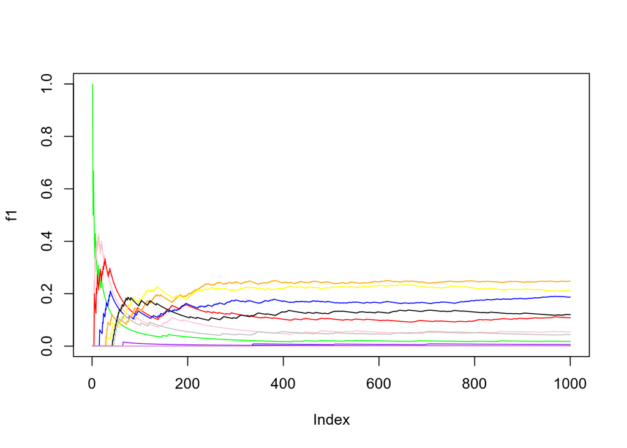

```r
#question 5
n=1000
b=simulation(1,n,M) # 1 simulation de 1000 étapes et on regarde combien de fois c'est dans l'état 1, 2,.. 11

f1=cumsum(b==1)/1:n
f2=cumsum(b==2)/1:n
f3=cumsum(b==3)/1:n
f4=cumsum(b==4)/1:n
f5=cumsum(b==5)/1:n
f6=cumsum(b==6)/1:n
f7=cumsum(b==7)/1:n
f8=cumsum(b==8)/1:n
f9=cumsum(b==9)/1:n
f10=cumsum(b==10)/1:n
f11=cumsum(b==11)/1:n

plot(f1,type='l',col='green',ylim=c(min(c(f1,f2,f3,f4,f5,f6,f7,f8,f9,f10,f11)),max(c(f1,f2,f3,f4,f5,f6,f7,f8,f9,f10,f11))))
lines(f2, col="pink")
lines(f3, col="red")
lines(f4,col="blue")
lines(f5, col="orange")
lines(f6, col="yellow")
lines(f7,col="black")
lines(f8, col="grey")
lines(f9, col="purple")
lines(f10,col="blue")
lines(f11, col="pink")
```

##Q6

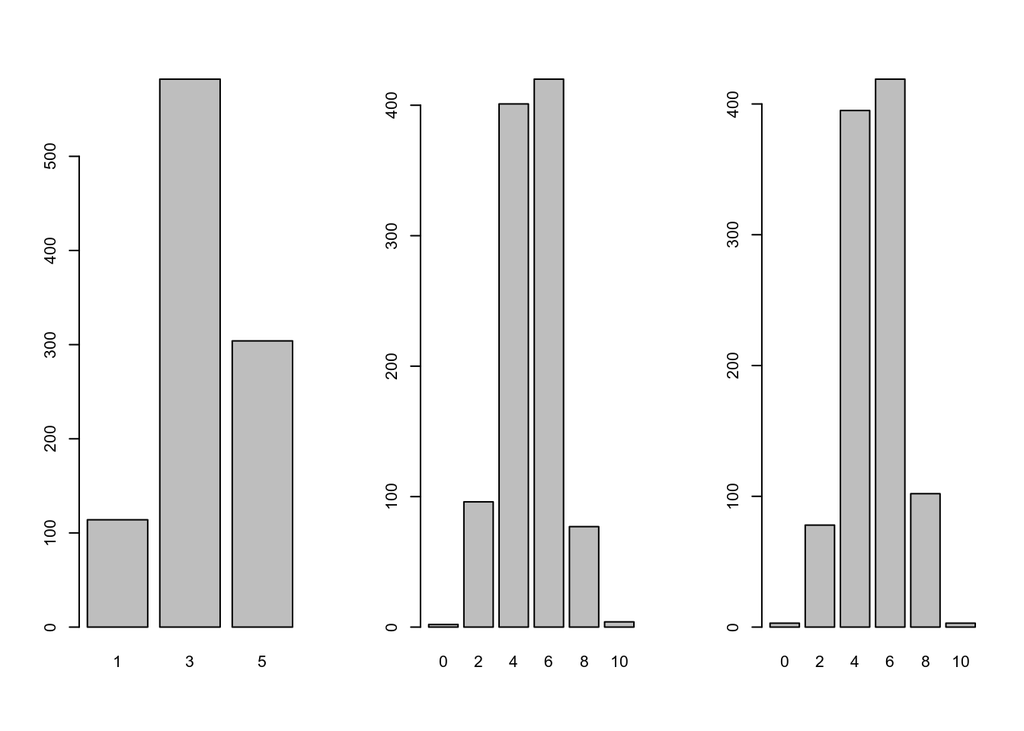

```r
# ou est ce qu'ils sont à l'étape 5,50,100 pour 1000 simulations
n=100
f=matrix(NA,1000,3)
for (i in 1 :1000)
{
  f[i,]=simulation(1,n,M)[c(5,50,100)]
}

par(mfrow=c(1,3))
barplot(table(f[,1]),beside = TRUE)
barplot(table(f[,2]),beside = TRUE)
barplot(table(f[,3]),beside = TRUE)
```